# Lyft Bay Wheel's trip dataset exploration

### bike_id

```python
# Get the values that is not NaN
bike = df.bike_id[~df.bike_id.isna()]
```

```python
bike.value_counts()
```

```
2174.0      2055
2692.0      2052
1161.0      2043
3379.0      2033
1396.0      2027
            ...
669634.0       1
228211.0       1
444238.0       1
666603.0       1
536010.0       1
Name: bike_id, Length: 15989, dtype: int64
```

Let's look at which bike was the most popular ones!

```python
# Top20 bikes!
bike_top20 = bike.value_counts().iloc[:20]
```

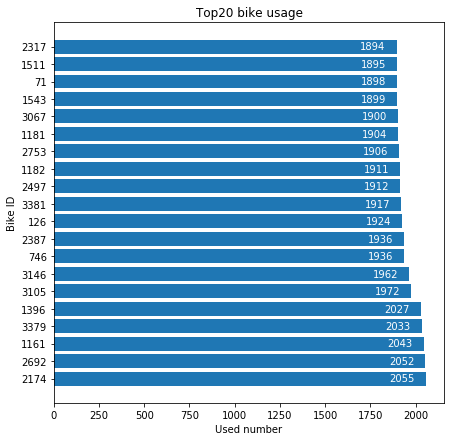

```python
plt.figure(figsize=[7, 7])
plt.barh(np.arange(20), bike_top20.values)
plt.yticks(np.arange(20), np.array(bike_top20.index).astype(int))
plt.title('Top20 bike usage')
plt.xlabel('Used number')
plt.ylabel('Bike ID')

# To show the count value of each
locs, labels = plt.yticks()
for loc, label in zip(locs, labels):
    count = bike_top20[float(label.get_text())]
    string = str(count)
    plt.text(count - 200, loc, string, va='center', color='w');
```

Bike id `2174` was the most used bike here! Now let's look at the distribution of the bike used number!

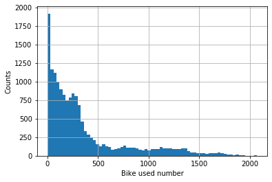

```python
interval = 30
bins = np.arange(0, bike.value_counts().max() + interval, interval)
bike.value_counts().hist(bins=bins)

plt.xlabel('Bike used number')
plt.ylabel('Counts');
```

📝 **comment** 🔔 🔎

Bike ID is categorical variable so we used barchart to see the total number of usage for each `top 20 bike id`.

- Bike id `2174` was the most used bike with **2055** times!

When we check the `distribution of bike usage` using histogram, we can see it's `right-skewed` and the bikes that used more than **500 times** is not a lot as we see in the visualization. Most of the bike was used less than 500 times.

Later we can check what station was the bike located that was mostly used? We can think the bike was mostly used because it was located at a place where there is a lot of traffic!

### Details of service

- user_type
- bike_share_for_all_trip
- rental_access_method
- rideable_type
- is_equity

```python
data = df.is_equity.value_counts()
data = data[~data.isna()]
```

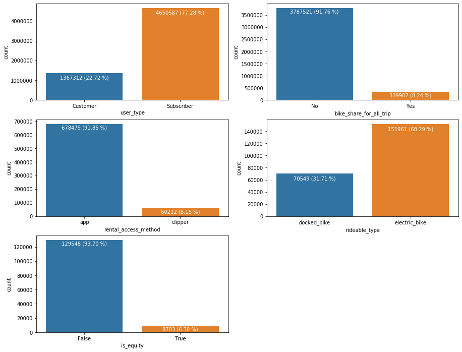

```python
service_details =['user_type',
                  'bike_share_for_all_trip',
                  'rental_access_method',
                  'rideable_type',
                  'is_equity']

plt.figure(figsize=[15, 12])

# iterate through the details and draw the plots!
for i, detail in enumerate(service_details):
    plt.subplot(3, 2, i+1)
    data = df['{}'.format(detail)]

    # Get the data that is not NaN
    data = data[~data.isna()]

    # Plot the graph
    sb.countplot(data=data.reset_index(), x='{}'.format(detail))

    # plot the count details
    data_dic = data.value_counts()
    data_len = len(data)

    locs, labels = plt.xticks()
    for loc, label in zip(locs, labels):
        # special case for is_equity because it is bool type
        if i == 4:
            # The kernel dies when I do data_dic[False]
            # data_dic[True] is fine
            # Don't know the reason why it brokes so simply use iloc to get the value
            text = label.get_text()
            if text == 'True':
                count = data_dic.iloc[1]
            elif text == 'False':
                count = data_dic.iloc[0]
        else:
            count = data_dic[label.get_text()]
        string = '{} ({:.2f} %)'.format(count, count/data_len*100)
        plt.text(loc, count - data_len/20, string, ha='center', color='w')
```

```python
# Drop this column because it seems ambiguous of the correct meaning
df.drop(columns='is_equity', inplace=True)

# Save the cleaned dataset using pickle
df.to_pickle('lyft_bay_wheel_master.pkl')
```

```python
# Check the dataframe using info
df.info()
```

```
<class 'pandas.core.frame.DataFrame'>
RangeIndex: 6017899 entries, 0 to 6017898
Data columns (total 16 columns):
 #   Column                   Non-Null Count    Dtype
---  ------                   --------------    -----
 0   duration_sec             5795389 non-null  Int64
 1   start_time               6017899 non-null  datetime64[ns]
 2   end_time                 6017899 non-null  datetime64[ns]
 3   start_station_id         5357347 non-null  object
 4   start_station_name       5359181 non-null  object
 5   start_station_latitude   6017863 non-null  float64
 6   start_station_longitude  6017863 non-null  float64
 7   end_station_id           5351587 non-null  object
 8   end_station_name         5353413 non-null  object
 9   end_station_latitude     6017416 non-null  float64
 10  end_station_longitude    6017416 non-null  float64
 11  bike_id                  5795389 non-null  object
 12  user_type                6017899 non-null  category
 13  bike_share_for_all_trip  4127428 non-null  category
 14  rental_access_method     738691 non-null   category
 15  rideable_type            222510 non-null   category
dtypes: Int64(1), category(4), datetime64[ns](2), float64(4), object(5)
memory usage: 579.7+ MB
```

📝 **comment** 🔔 🔎

Because this is all categorical and doesns't have much to dig on just simply visualize all 5 columns using `bar chart`. But this is not applied to most of the bike data so we could just consider this information as additional reference details.

- `user_type` **6017899 (100%)**
- `bike_share_for_all_trip` **4127428 (68.58%)**
- `rental_access_method` **738691 (12.27%)**
- `rideable_type` **222510 (3.69%)**
- `is_equity` **138251 (2.29%)**

As you can see the amount of data is not enough.

- Most of the users are `Subscriber`s for **77.28%**
- Most of the users doens't use `bike share for all trip` service **91.76%**
- `App` is the most popular method to pay for bike rental **91.85%**. `clipper` is also used
- `electric bike` has high proportion between bikes **68.29%**
- **93.70** of bikes are not equity

In case of `is_equity` column is quite ambiguous what it actually means. So we are not going to use it for analysing any further so I dropped this column. Also due to the amount of data `user_type` and `bike_share_for_all_trip` seems useful data to analyze. We will use this 2 columns further.

### Discuss the distribution(s) of your variable(s) of interest. Were there any unusual points? Did you need to perform any transformations? 🔔

> This is lyft bike trip data so `time` and `space` because our main interest is when and where of bike service! When the user use the bike at what time? We only did **univariate exploration** so cannot analyze in-depth but we could understand the distribution of variables related to `time` and `space`.

**When does the user mostly use the bike?**

We need to transform the **datetime** for each `month`, `day`, and `hour` to analyze this one.

For `month` and `day` the user usage was not that different. It was interesting that user usage goes lower at `December` and reach the highest at `February`. We can think that maybe because of weather. If we want to go into details we could consider gathering addtional weather data to analyze this. In case of `day` it was close to **uniform distribution**.

Users mostly use bike `8-9 am & 5-6 pm`. We could assume that maybe the user of bike service are mostly an office worker who commutes by bike. So we know when the user start to use the bike.

Then **how long they ride it?**

`Bike use time` was forming **normal distribution** in `log scale`. There were some outliers using the bike more than **10 days** but its pretty unusual. Most of the people were using bike less than **1 hour** and **6 minutes** usage was showing the highest proportion among all the usage time. Seems most of the users move by bike only for short distance and use car for more further distance.

Then **where are the users starting to ride the bike?**

We know they don't really need to use a long time.

- total `507` spot that bike was parked for both start station and end station.
- For `start station`, `Market St at 10th St` is the most popular station.
- For `end station`, `San Francisco Caltrain (Townsend St at 4th St)` is the most popular station.
- Start station top 10 and End station top 10 has 9 station the same. This means people mostly start to use bike from here and end here.

We can think that users are using **subway** or **train** and after that they use `bike` to reach the place they want to go! When we see this in details using `longitude` and `latitude` information we could see the followings.

- Most of the `station bike usage` is around **longitude** `-122.39`, `-122.28`, and `-121.88`
- Most of the `station bike usage` is around **latitude** `37.33` and `37.77`

We could think that this place are pointing at the lyft 3 service area.

**Lyft bike station**

- San Francisco
- East Bay
- San Jose

For each popular are the distribution for each spot is `left-skewed` in **longitude** and `bimodal` in **Latitude**. Maybe we could find popular `Public transportation` spot when we track this.

We could be curious about **how many bikes are used for the service?**

### Of the features you investigated, were there any unusual distributions? Did you perform any operations on the data to tidy, adjust, or change the form of the data? If so, why did you do this? 🔔

> Gladly there were no odd or unusual distributions of the data were predictable and shown correct.

The **datetime** that was showing us the user bike `start time` and `end time` here were no data to be changed. In case of **datetime** we cannot use the data itself which was following the format `YYYY-MM-DD hh:mm:ss` so had to extract each `year`, `month`, `day`, and `hour`.

The **longitude** and **latitude** data includes wrong data. It shows the location where the service of lyft bike sharing operates is among the USA but actually this is not right. The service is limited to `California`.

**Lyft bike station**

- San Francisco
- East Bay
- San Jose

We could consider there is some noise inside the `longitude` and `latitude` data and removed the data that is outside the service area. Not quite sure why this wrong `longitude` and `latitude` was inside because didn't dive in deeper but can make assumptions that in the past the lyft service were held in other `province` but was withdrawed or it was just a mistake of the backend server.

**is_equity** column has ambiguous meaning and searched for it but didn't find it. So I simply dropped this column. Also this column had **138251 rows** of data so it doesn't had a valuable number of data neither.

## Bivariate Exploration ✅

**bivariate visualization**

- Scatter plots - `quantitative variables` vs `quantitative variables`
- Heat maps - `quantitative variables` vs `quantitative variables`
  - **Good for discrete variable vs discrete variable**
- Violin plots - `quantitative variables` vs `qualitative variables`
- Box plots - `quantitative variables` vs `qualitative variables`
- Clustered bar charts - `qualitative variables` vs `qualitative variables`
- Faceting
- Adaption of univariate plots
  - `Bar plots`
  - `Histogram`

**explore**

- `Bike usage time for each start time hour`
- `Datetime the user mostly start to use the bike`
- `The bike station people use most at 8am and 5pm`
- `User bike trip route`
- `Location of the 10 most frequently used bikes`
- `user_type` vs `bike_share_for_all_trip`

### Bike usage time for each start time hour

We are going see how long does the user ride the bike for each rental hour.

```python
# make a new copy of original to add new column "hour"
bike_df = df.copy()

# Generate column "hour"
bike_df['hour'] = bike_df.start_time.dt.hour

# leave the necessary columns
bike_df = bike_df[['hour', 'duration_sec']]

# Remove NaN values
bike_df = bike_df[~(bike_df.hour.isna() | bike_df.duration_sec.isna())]

# Check values
bike_df.sample(5)
```

|  | hour | duration_sec |
| --- | --- | --- |
| 2716798 | 18 | 810 |
| 1923422 | 7 | 134 |
| 2052948 | 16 | 734 |
| 1480510 | 19 | 178 |
| 2177126 | 8 | 887 |

```python
# bike_df duration_sec is consisted with pd.array pd.Int64Dtype so we have to change it to int64 using astype
# This is necessary for DataFrame.query!
bike_df.duration_sec = bike_df.duration_sec.astype(int)
```

```python
bike_df.query('duration_sec > 100000')
```

|  | hour | duration_sec |
| --- | --- | --- |
| 4864675 | 23 | 912110 |
| 5011550 | 16 | 811077 |

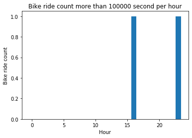

```python
# bike data that was ride more than 100000 sec
bike100000_dic = bike_df.query('duration_sec > 100000').hour.value_counts()

# plot bar graph
plt.bar(np.arange(24), [bike100000_dic.get(i, 0) for i in range(24)])
plt.title('Bike ride count more than 100000 second per hour')
plt.xlabel('Hour')
plt.ylabel('Bike ride count');
```

We can see that only two data has more than **100000 sec**

- 4pm **811077 sec**
- 11pm **912110 sec**

Let's remove this data and consider the `xticks` below **100000**!

```python
bike_df = bike_df.query('duration_sec <= 100000')
```

Also, to draw `FacetGrid` the cost of calculating is quite high. It means we need to lower the calcuation.

```python
bike_df.query('duration_sec > 10000').count()[0]
```

```
23335
```

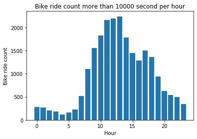

```python
# bike data that was ride more than 10000 sec
bike10000_dic = bike_df.query('duration_sec > 10000').hour.value_counts()

# plot bar graph
plt.bar(np.arange(24), [bike10000_dic[i] for i in range(24)])
plt.title('Bike ride count more than 10000 second per hour')
plt.xlabel('Hour')
plt.ylabel('Bike ride count');
```

```python
bike_df = bike_df.query('duration_sec <= 10000')
```

And we can see most of the people ride the bike while around **noon**. When we think about the most bike ride came around **8am** and **18pm** this is interesting. When we only consider long ride seems many riders are not mostly using bikes for commuting to the company.

Let's remove this also to draw the `FacetGrid`.

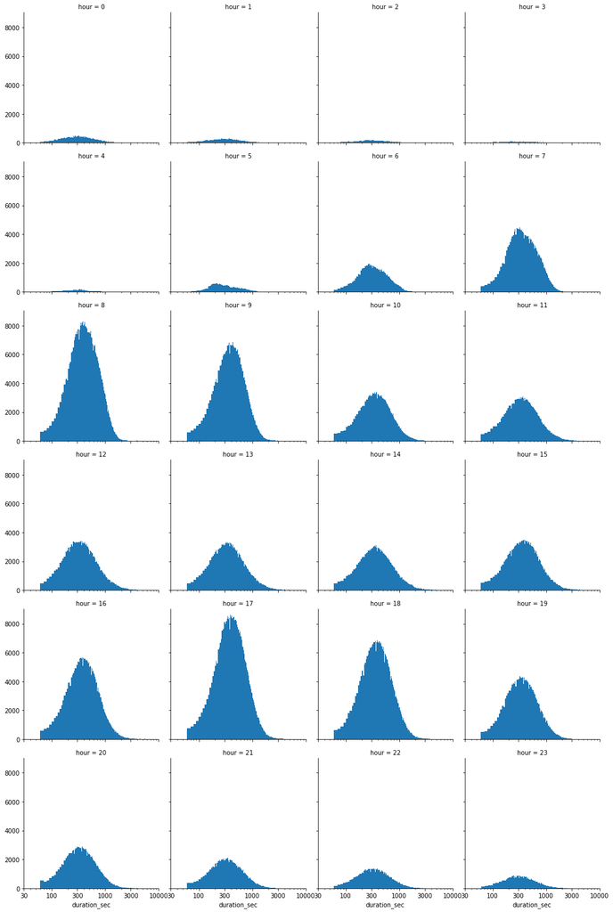

```python
loc = [30, 100, 300, 1000, 3000, 10000]

g = sb.FacetGrid(data=bike_df, col='hour', col_wrap=4, height=3.5)
g.map(plt.hist, 'duration_sec', bins=1000).set(xscale='log')
g.set(xticks=loc, xticklabels=loc, xlim=[30, 10000]);
```

📝 **comment** 🔔 🔎

The point here is to get insight of the `bike usage time` for **each start time hour**. So I used `FacetGrid` with `histogram` because this is pair of `categorical` and `numeric` variable.

Different from expectation the distribution showed **normal distribution** in log scale for all hours. The expectation was that the peak(mean) of normal distribution might vary a lot depending on the `hour` but it was wrong. Still most of the user use the bike for **6 minutes** no matter what time is it.

The difference I could see is that the `total usage count` due to the `hour`.

We saw that **user use the bike with the same pattern no matter with the time**. Now let's look deeper **when the user mostly start to use the bike?**

### Datetime the user mostly start to use the bike

```python
# make a new copy of original
bike_df = df.copy()

# Generate necessary columns
bike_df['year'] = bike_df.start_time.dt.year
bike_df['month'] = bike_df.start_time.dt.month
bike_df['day'] = bike_df.start_time.dt.day
bike_df['hour'] = bike_df.start_time.dt.hour

# leave the necessary columns
bike_df = bike_df[['year', 'month', 'day', 'hour']]

# Remove NaN values
bike_df = bike_df[~(bike_df.year.isna() |
                    bike_df.month.isna() |
                    bike_df.day.isna() |
                    bike_df.hour.isna())]

# Check values
bike_df.sample(5)
```

|  | year | month | day | hour |
| --- | --- | --- | --- | --- |
| 202615 | 2017 | 10 | 26 | 8 |
| 3103273 | 2019 | 4 | 17 | 9 |
| 3016377 | 2019 | 4 | 30 | 18 |
| 5688960 | 2020 | 3 | 13 | 12 |
| 621685 | 2018 | 2 | 27 | 9 |

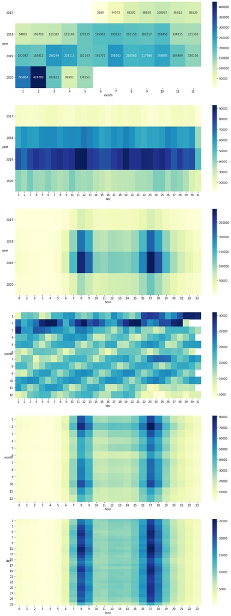

```python
columns = ['year', 'month', 'day', 'hour']

# figure size
plt.figure(figsize=[15, 40])

# permutation without i exceeding j
# ex) [0, 1], [0, 2], [0, 3], [1, 2], [1, 3], [2, 3]
ax_num = 1
for i in range(4):
    for j in range(i+1, 4):
        # choose the axes
        plt.subplot(6, 1, ax_num)
        ax_num += 1

        # Choose what columns will be used for plot
        row = columns[i]
        column = columns[j]

        # groupby with row and column
        bike_table = bike_df.groupby(['{}'.format(row), '{}'.format(column)]).count().reset_index()

        # Get the remain column
        k = list(set([0, 1, 2, 3]) ^ set([i, j]))[0]
        count = columns[k]

        # pivot the table to be able to apply heatmap
        bike_table = bike_table.pivot(index='{}'.format(row),
                                      columns='{}'.format(column),
                                      values='{}'.format(count))

        # plot the heatmap
        if ax_num == 2:
            annot_bool = True
        else:
            annot_bool = False
        sb.heatmap(bike_table, annot=annot_bool, fmt='g', cmap='YlGnBu')
        plt.yticks(rotation=1)
        plt.ylabel('{}'.format(row), rotation=1);
```

# 📝 **comment** 🔔 🔎

I wanted to see the **relative bike usage frequency** of `start time`. I tranform the `datetime` of **start_time** to `year`, `month`, `day`, and `hour`. Datas are discrete cateogorical variables so it would be good to use heatmap here.

**Date people mostly use the bikes**

- `2020 February`
- `2019 11-12th`
- `2019 8am and 5pm`
- `February 8am and 5pm`
- `11-12th 8am and 5pm`

`month` and `day` pair shows interesting results. When we see the heatmap we can see the **most frequent days** among `months` are acting like there is some period.

- `January` 3, 10, 17, 23, 30 **(day)**
- `February` 6, 12, 20, 28
- `March` 4, 12, 19, 27
- `April` 3, 10, 18, 25
- `May` 2, 9, 16, 23, 30

and so on. If you check the heatmap above you will notice the `diagonal pattern` showing. **Why people bike usage days does not stuck in one days like 11-12th and move to backward like `moving window`**? That was weird.

Now We can think of **February** and **8am & 5pm** is the time that people use bike a lot! Let's check where people are using bike at this moments! Because this is bivariate exploration we can only choose `month` or `hour` so we are going to explore the `bike station` with `hour`!

### The bike station people use most at 8am and 5pm

```python
# make a new copy of original to add new column "hour"
bike_df = df.copy()

# Generate column "hour"
bike_df['hour'] = bike_df.start_time.dt.hour

# leave the necessary columns
bike_df = bike_df[['hour', 'start_station_name', 'end_station_name']]

# Remove NaN values
bike_df = bike_df[~(bike_df.hour.isna() |
                    bike_df.start_station_name.isna() |
                    bike_df.end_station_name.isna())]

# Check values
bike_df.sample(5)
```

|  | hour | start_station_name | end_station_name |
| --- | --- | --- | --- |
| 783197 | 13 | 14th St at Mission St | Bryant St at 6th St |
| 922392 | 9 | 32nd St at Adeline St | West Oakland BART Station |
| 3176778 | 9 | San Francisco Caltrain (Townsend St at 4th St) | Townsend St at 7th St |
| 2029118 | 15 | Market St at Dolores St | Market St at 10th St |
| 4851649 | 18 | 2nd Ave at E 18th St | Lakeside Dr at 14th St |

Now let's leave only `8am` and `5pm` information!

```python
# Leave only 8am and 5pm
bike_df_8_17 = bike_df.query('hour in [8, 17]')
```

```python
bike_df_8_17.start_station_name.value_counts().iloc[:10]
```

```
San Francisco Caltrain (Townsend St at 4th St)               30530
San Francisco Caltrain Station 2  (Townsend St at 4th St)    28242
San Francisco Ferry Building (Harry Bridges Plaza)           27622
Berry St at 4th St                                           26721
Howard St at Beale St                                        22916
Montgomery St BART Station (Market St at 2nd St)             22842
Market St at 10th St                                         22570
Steuart St at Market St                                      20779
The Embarcadero at Sansome St                                17253
Powell St BART Station (Market St at 4th St)                 16613
Name: start_station_name, dtype: int64
```

```python
bike_df_8_17.end_station_name.value_counts().iloc[:10]
```

```
San Francisco Caltrain Station 2  (Townsend St at 4th St)    41604
San Francisco Caltrain (Townsend St at 4th St)               38507
Montgomery St BART Station (Market St at 2nd St)             32435
San Francisco Ferry Building (Harry Bridges Plaza)           32031
Berry St at 4th St                                           26665
Market St at 10th St                                         23567
The Embarcadero at Sansome St                                21325
Howard St at Beale St                                        21072
Powell St BART Station (Market St at 4th St)                 20452
Steuart St at Market St                                      18890
Name: end_station_name, dtype: int64
```

We can see `San Francisco Caltrain` is the station most popular at `8am and 5pm`

Now let's check the `top 5 start station`'s **bike start time** distribution!

```python
top5 = list(bike_df_8_17.start_station_name.value_counts().iloc[:5].index)
top5
```

```
['San Francisco Caltrain (Townsend St at 4th St)',
 'San Francisco Caltrain Station 2  (Townsend St at 4th St)',
 'San Francisco Ferry Building (Harry Bridges Plaza)',
 'Berry St at 4th St',
 'Howard St at Beale St']
```

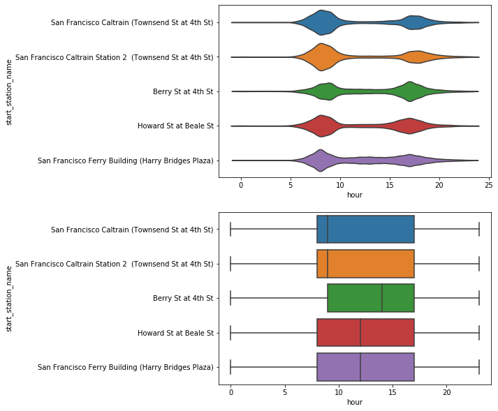

```python
plt.figure(figsize=[7, 10])

# violinplot
plt.subplot(211)
sb.violinplot(data=bike_df.query('start_station_name in @top5'),
              x='hour', y='start_station_name', inner=None)

# boxplot
plt.subplot(212)
sb.boxplot(data=bike_df.query('start_station_name in @top5'),
           x='hour', y='start_station_name');
```

```python
top5 = list(bike_df_8_17.end_station_name.value_counts().iloc[:5].index)
top5
```

```
['San Francisco Caltrain Station 2  (Townsend St at 4th St)',
 'San Francisco Caltrain (Townsend St at 4th St)',
 'Montgomery St BART Station (Market St at 2nd St)',
 'San Francisco Ferry Building (Harry Bridges Plaza)',
 'Berry St at 4th St']
```

Let's do the same thing with `end_station`

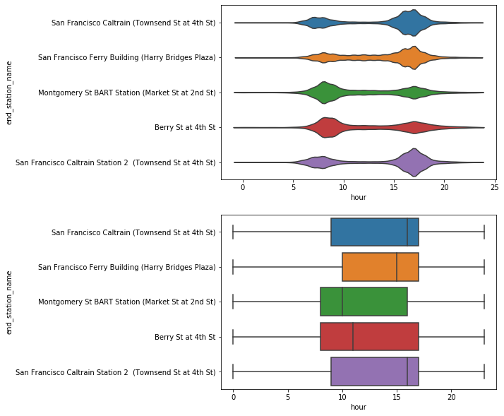

```python
plt.figure(figsize=[7, 10])

# violinplot
plt.subplot(211)
sb.violinplot(data=bike_df.query('end_station_name in @top5'),
              x='hour', y='end_station_name', inner=None)

# boxplot
plt.subplot(212)
sb.boxplot(data=bike_df.query('end_station_name in @top5'),
           x='hour', y='end_station_name');
```

📝 **comment** 🔔 🔎

The `station name` is qualitative and `hour` is quantitative so we used **violin plots** and **box plots**.

- `San Francisco Caltrain` is the station most popular at **8am and 5pm**

When we get **Top 5** `start station` and `end station` at **8am and 5pm** usage distribution paired with hour we can the following.

- People start to use bike near **public transportation** at `8am` more than `5pm`
- People end the use of bike near **public transportation** at `5pm` more than `8am`

`Berry St at 4th St` acts opposite with the above explanation. If we dive more deep this kind of `station` will came our more. We can make assumption that people using `caltrain` is coming from other area to work and people who lives at `San Francisco` go to work using bike near `Berry St at 4th St`.

There is a difference of amount of usage to or from **public transportation** based on the time but still `8am` and `5pm` has the most usage for both `start station` and `end station` near **public transportation**.

Now let's look at the **route of the user riding a bike**!

### User bike trip route

```python
# make a new copy of original to add new column "hour"
bike_df = df.copy()

# leave the necessary columns
bike_df = bike_df[['duration_sec', 'start_station_name', 'end_station_name']]

# Remove NaN values
bike_df = bike_df[~(bike_df.start_station_name.isna() |
                    bike_df.end_station_name.isna())]

# Check values
bike_df.sample(5)
```

|  | duration_sec | start_station_name | end_station_name |
| --- | --- | --- | --- |
| 4018152 | 1174 | Masonic Ave at Turk St | 3rd St at Townsend St |
| 679328 | 920 | San Francisco Public Library (Grove St at Hyde... | Webster St at Grove St |
| 3219390 | 372 | Mission Dolores Park | Dolores St at 15th St |
| 2229036 | 475 | Dover St at 57th St | MacArthur BART Station |
| 2295351 | 449 | Berry St at 4th St | Montgomery St BART Station (Market St at 2nd St) |

```python
route = bike_df.groupby(['start_station_name', 'end_station_name']).count().reset_index()
route.rename(columns={'duration_sec': 'count'}, inplace=True)
```

```python
# sort by count
route = route.sort_values(by='count', ascending=False)
```

```python
route.iloc[:10]
```

|  | start_station_name | end_station_name | count |
| --- | --- | --- | --- |
| 53777 | San Francisco Ferry Building (Harry Bridges Pl... | The Embarcadero at Sansome St | 16313 |
| 16319 | Berry St at 4th St | San Francisco Ferry Building (Harry Bridges Pl... | 11621 |
| 59458 | The Embarcadero at Sansome St | Steuart St at Market St | 10460 |
| 31451 | Grand Ave at Perkins St | 19th Street BART Station | 9164 |
| 59452 | The Embarcadero at Sansome St | San Francisco Ferry Building (Harry Bridges Pl... | 9021 |
| 4155 | 19th Street BART Station | Grand Ave at Perkins St | 8812 |
| 53623 | San Francisco Ferry Building (Harry Bridges Pl... | Berry St at 4th St | 8120 |
| 57376 | Steuart St at Market St | The Embarcadero at Sansome St | 7406 |
| 40553 | Market St at 10th St | Powell St BART Station (Market St at 4th St) | 6844 |
| 15449 | Bay Pl at Vernon St | 19th Street BART Station | 6780 |

We can see lots of route going back and forth around `San Francisco`.

Now let's only leave the stations which includes `Top10`

```python
start_top10 = route.iloc[:10].start_station_name
end_top10 = route.iloc[:10].end_station_name
```

```python
# Get the start station and end station only for top10
bike_top10 =  bike_df.query('start_station_name in @start_top10 and end_station_name in @end_top10')
```

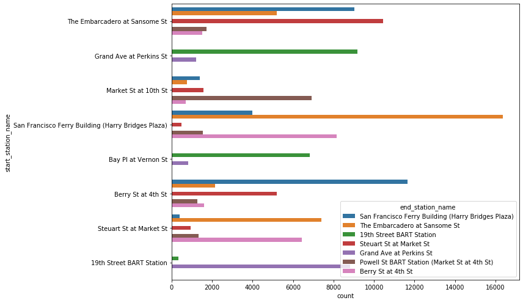

```python
# top10
plt.figure(figsize=[12, 7])
sb.countplot(data=bike_top10, y='start_station_name', hue='end_station_name')
plt.tight_layout();
```

Let's look at this in a different view in heatmap!

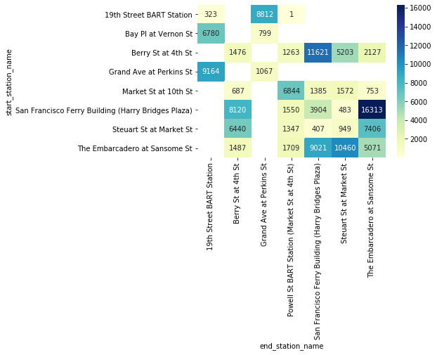

```python
bike_top10 = bike_top10.groupby(['start_station_name', 'end_station_name']).count().reset_index()
bike_top10.rename(columns={'duration_sec': 'count'}, inplace=True)

bike_top10 = bike_top10.pivot(index='start_station_name', columns='end_station_name', values='count')

sb.heatmap(bike_top10, annot=True, fmt='g', cmap='YlGnBu');
```

One thing I noticed is that some `start station` and `end station` is the same! It means user is riding bike for the purpose to ride a bike not to go somewhere! Let's check this more!

```python
# Get the data that start station and end station are the same
bike_same =  bike_df.query('start_station_name == end_station_name')

# total count for each station of the user comeback to where they started to ride the bike
bike_same = bike_same.groupby('start_station_name').count().reset_index().drop(columns=['end_station_name'])

# rename the columns
bike_same.rename(columns={'start_station_name': 'station', 'duration_sec': 'count'}, inplace=True)

# Sort the value based on the count
bike_same.sort_values('count', ascending=False, inplace=True)
```

```python
bike_same.info()
```

```
<class 'pandas.core.frame.DataFrame'>
Int64Index: 504 entries, 460 to 44
Data columns (total 2 columns):
 #   Column   Non-Null Count  Dtype
---  ------   --------------  -----
 0   station  504 non-null    object
 1   count    504 non-null    int64
dtypes: int64(1), object(1)
memory usage: 11.8+ KB
```

There are **504** station that user used the bike just for wandering around and comeback!

```python
# top 20
bike_top20 = bike_same.iloc[:20][::-1]
bike_top20
```

|  | station | count |
| --- | --- | --- |
| 247 | Grand Ave at Perkins St | 1067 |
| 127 | Bay St at Fillmore St | 1169 |
| 124 | Bancroft Way at Telegraph Ave | 1173 |
| 299 | Lakeside Dr at 14th St | 1179 |
| 305 | Lombard St at Columbus Ave | 1201 |
| 162 | Civic Center/UN Plaza BART Station (Market St ... | 1264 |
| 106 | Addison St at Fourth St | 1307 |
| 313 | Market St at 10th St | 1408 |
| 130 | Berry St at 4th St | 1476 |
| 462 | The Embarcadero at Vallejo St | 1513 |
| 381 | Powell St BART Station (Market St at 5th St) | 1659 |
| 380 | Powell St BART Station (Market St at 4th St) | 1781 |
| 407 | San Francisco Caltrain (Townsend St at 4th St) | 2004 |
| 149 | Buchanan St at North Point St | 2040 |
| 70 | 3rd St at Townsend St | 2258 |
| 209 | Fell St at Stanyan St | 2707 |
| 193 | El Embarcadero at Grand Ave | 2722 |
| 155 | Central Ave at Fell St | 3132 |
| 411 | San Francisco Ferry Building (Harry Bridges Pl... | 3904 |
| 460 | The Embarcadero at Sansome St | 5071 |

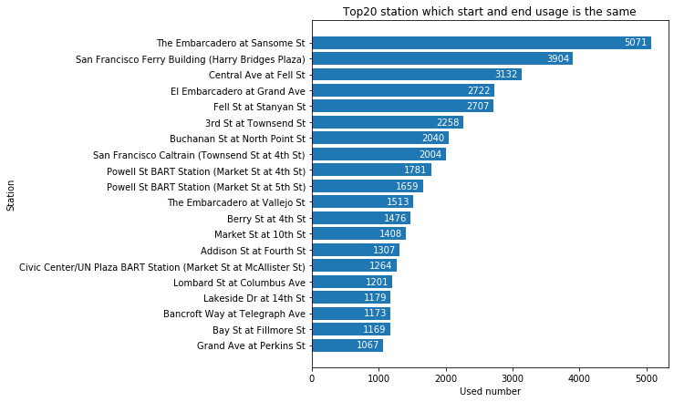

```python
plt.figure(figsize=[7, 7])
plt.barh(np.arange(20), bike_top20['count'])
plt.yticks(np.arange(20), bike_top20.station)
plt.title('Top20 station which start and end usage is the same')
plt.xlabel('Used number')
plt.ylabel('Station')

# To show the count value of each
locs, labels = plt.yticks()
for i, (loc, label) in enumerate(zip(locs, labels)):
    count = bike_top20['count'].iloc[i]
    plt.text(count - 400, loc, s=count, va='center', color='w')
```

**The Embarcadero and Sansome station**

[figure not shown]

If they are using bike for simple ride to look around than how long will they ride the bike?

```python
# Get the data that start station and end station are the same
bike_same =  bike_df.query('start_station_name == end_station_name')

# Top 10
top10 = bike_top20[::-1][:10].station.values

# Leave only station that is in top10 station
bike_same = bike_same.query('start_station_name in @top10')

# drop unnecessary column
bike_same.drop(columns=['end_station_name'], inplace=True)

# rename the columns
bike_same.rename(columns={'start_station_name': 'station'}, inplace=True)

# reset index
bike_same = bike_same.reset_index(drop=True)

######## The below process is important to use sb.violinplot and sb.boxplot
# they don't accept the dtype that is pd.Int64Dtype in pd.array
########

# Remove NaN values
bike_same = bike_same[~(bike_same.duration_sec.isna())]

# Change dtype from pd.array pd.Int64Dtype to pandas int
bike_same.duration_sec = bike_same.duration_sec.astype(int)

# change duration_sec to minute to see more easy for human being QUARK
bike_same.duration_sec = bike_same.duration_sec/60

# rename second to minute
bike_same.rename(columns={'duration_sec': 'minute'}, inplace=True)
```

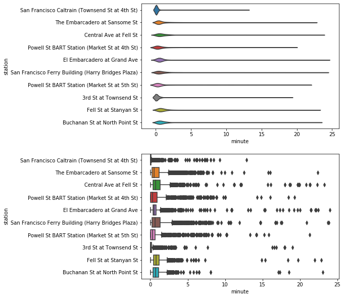

```python
plt.figure(figsize=[7, 10])

# violinplot
plt.subplot(211)
sb.violinplot(data=bike_same, x='minute', y='station', inner=None)

# boxplot
plt.subplot(212)
sb.boxplot(data=bike_same, x='minute', y='station');
```

```python
len(bike_same.query('minute < 5')) / len(bike_same)
```

```
0.9828433169587213
```

`98.2%` of users ride bike for less than 5 mintues!

📝 **comment** 🔔 🔎

To find the route we need the `start station name` and `end station name`. By grouping up with **start and end station** we could find which route is the most popular route!

- `San Francisco Ferry Building (Harry Bridges Plaza)` to `The Embarcadero at Sansome St`
- 16313 times used

I used `clustered bar chart` and `heatmap` to check the trend of route but seems hard to get intuitive understanding. We need a map that shows the route for precise understanding! Even I limited the number of station to `top10` it seems messy! One thing I found interesting is users end using the bike where they rental it! It means they are not using bike to move to somewhere. Rather they are using bike for wandering around for travel.

Then we could think about what station is the most popular one to comeback after riding?

- Total **504** station are used like this!
- `The Embarcadero at Sansome St` is the popular one recording `5071` times!

**Then how long they ride for this purpose? Just to look around and comeback?**

- **98.2%** of users ride less than `5 minutes`
- Other **1.8%** users ride more than `5 minutes` doesn't exceed **`25 minutes`**

We now know what route the user mostly prefer. We know that **some bikes are used a lot compared to others**. Now let's track these bikes. **Where does these bikes are located?**

### Location of the 10 most frequently used bikes

```python
# make a new copy of original
bike_df = df.copy()

# leave the necessary columns
bike_df = bike_df[['bike_id', 'start_station_name', 'end_station_name']]

# Remove NaN values
bike_df = bike_df[~(bike_df.bike_id.isna() |
                    bike_df.start_station_name.isna() |
                    bike_df.end_station_name.isna())]

# Check values
bike_df.sample(5)
```

|  | bike_id | start_station_name | end_station_name |
| --- | --- | --- | --- |
| 4687967 | 10547 | Fountain Alley at S 2nd St | Santa Clara St at Almaden Blvd |
| 731294 | 2003 | The Embarcadero at Sansome St | San Francisco Ferry Building (Harry Bridges Pl... |
| 4792093 | 2743 | Indiana St at Cesar Chavez St | 4th St at Mission Bay Blvd S |
| 1560406 | 999 | MacArthur BART Station | 47th St at San Pablo Ave |
| 994245 | 3492 | Howard St at 8th St | Koshland Park |

```python
# Get the bike that mostly used
top10_bike = list(bike_df.bike_id.value_counts().iloc[:10].index)
top10_bike
```

```
[2174.0, 2692.0, 1161.0, 3379.0, 1396.0, 3105.0, 3146.0, 746.0, 2387.0, 126.0]
```

```python
# Leave the information of the top10 bikes
bike_10 = bike_df.query('bike_id in @top10_bike')
bike_10
```

|  | bike_id | start_station_name | end_station_name |
| --- | --- | --- | --- |
| 161 | 2692 | Harrison St at 20th St | Garfield Square (25th St at Harrison St) |
| 349 | 746 | Page St at Scott St | Page St at Scott St |
| 478 | 1396 | Precita Park | 11th St at Natoma St |
| 617 | 1396 | Golden Gate Ave at Polk St | Precita Park |
| 760 | 2692 | Harrison St at 17th St | Harrison St at 20th St |
| ... | ... | ... | ... |
| 5678870 | 3105 | Dolores St at 15th St | Embarcadero BART Station (Beale St at Market St) |
| 5679056 | 1396 | Broadway at Kearny St | Commercial St at Montgomery St |
| 5679174 | 3105 | 17th & Folsom Street Park (17th St at Folsom St) | Dolores St at 15th St |
| 5679946 | 3146 | Valencia St at 22nd St | Pier 1/2 at The Embarcadero |
| 5680770 | 126 | El Embarcadero at Grand Ave | 19th Street BART Station |

19940 rows × 3 columns

We are going to look at where the top10 bikes are located. So the `start` and `end` doens't matter.

Use `pd.melt` to merge the `start_station_name` and `end_station_name` in one column!

```python
# MELT!
bike_10 = pd.melt(bike_10, id_vars=['bike_id'], var_name='station', value_name='location')
bike_10
```

|  | bike_id | station | location |
| --- | --- | --- | --- |
| 0 | 2692 | start_station_name | Harrison St at 20th St |
| 1 | 746 | start_station_name | Page St at Scott St |
| 2 | 1396 | start_station_name | Precita Park |
| 3 | 1396 | start_station_name | Golden Gate Ave at Polk St |
| 4 | 2692 | start_station_name | Harrison St at 17th St |
| ... | ... | ... | ... |
| 39875 | 3105 | end_station_name | Embarcadero BART Station (Beale St at Market St) |
| 39876 | 1396 | end_station_name | Commercial St at Montgomery St |
| 39877 | 3105 | end_station_name | Dolores St at 15th St |
| 39878 | 3146 | end_station_name | Pier 1/2 at The Embarcadero |
| 39879 | 126 | end_station_name | 19th Street BART Station |

39880 rows × 3 columns

```python
bike_10.location.value_counts()
```

```
San Francisco Ferry Building (Harry Bridges Plaza)           1179
San Francisco Caltrain Station 2  (Townsend St at 4th St)    1164
San Francisco Caltrain (Townsend St at 4th St)               1057
Market St at 10th St                                         1018
Berry St at 4th St                                            966
                                                             ...
Market St at Park St                                            1
McKinnon Ave at 3rd St                                          1
Frank H Ogawa Plaza                                             1
Webster St at 17th St                                           1
Otis St at Brady St                                             1
Name: location, Length: 300, dtype: int64
```

There are **300 stations** that top10 bikes used at. But this is too many to plot. Let's only focus on the `top10 station`.

```python
top10_station = list(bike_10.location.value_counts().iloc[:10].index)
```

```python
top10 = bike_10.query('location in @top10_station').copy()
top10
```

|  | bike_id | station | location |
| --- | --- | --- | --- |
| 8 | 3146 | start_station_name | The Embarcadero at Sansome St |
| 11 | 3146 | start_station_name | The Embarcadero at Sansome St |
| 26 | 1161 | start_station_name | San Francisco Caltrain (Townsend St at 4th St) |
| 27 | 1161 | start_station_name | San Francisco Ferry Building (Harry Bridges Pl... |
| 32 | 1161 | start_station_name | Montgomery St BART Station (Market St at 2nd St) |
| ... | ... | ... | ... |
| 39841 | 3146 | end_station_name | Montgomery St BART Station (Market St at 2nd St) |
| 39843 | 3379 | end_station_name | San Francisco Caltrain (Townsend St at 4th St) |
| 39850 | 1161 | end_station_name | San Francisco Caltrain (Townsend St at 4th St) |
| 39854 | 1161 | end_station_name | San Francisco Caltrain (Townsend St at 4th St) |
| 39858 | 2387 | end_station_name | Market St at 10th St |

9687 rows × 3 columns

```python
# Make a rank index for sort!
bike_index = dict(zip(top10_bike, range(len(top10_bike))))
location_index = dict(zip(top10_station, range(len(top10_station))))

# Add a rank column for bike and location
top10['bike_rank'] = top10.bike_id.map(bike_index)
top10['location_rank'] = top10.location.map(location_index)

# Sort the value
top10.sort_values(['bike_rank', 'location_rank'], inplace=True)

# drop the rank column
top10.drop(columns=['bike_rank', 'location_rank'], inplace=True)

# Change bike_id int to object
top10.bike_id = top10.bike_id.astype('object')
```

```python
top10
```

|  | bike_id | station | location |
| --- | --- | --- | --- |
| 961 | 2174 | start_station_name | San Francisco Ferry Building (Harry Bridges Pl... |
| 1172 | 2174 | start_station_name | San Francisco Ferry Building (Harry Bridges Pl... |
| 2293 | 2174 | start_station_name | San Francisco Ferry Building (Harry Bridges Pl... |
| 2616 | 2174 | start_station_name | San Francisco Ferry Building (Harry Bridges Pl... |
| 2666 | 2174 | start_station_name | San Francisco Ferry Building (Harry Bridges Pl... |
| ... | ... | ... | ... |
| 34949 | 126 | end_station_name | Howard St at Beale St |
| 35344 | 126 | end_station_name | Howard St at Beale St |
| 35853 | 126 | end_station_name | Howard St at Beale St |
| 37057 | 126 | end_station_name | Howard St at Beale St |
| 37699 | 126 | end_station_name | Howard St at Beale St |

9687 rows × 3 columns

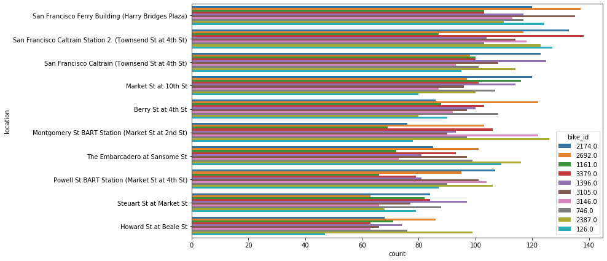

```python
# top10
plt.figure(figsize=[12, 7])
sb.countplot(data=top10, y='location', hue='bike_id', hue_order=top10_bike);
```

📝 **comment** 🔔 🔎

The `station name` is category and `bike_id` is also category so I used `clustered bar chart` to visualize!

**The 10 most popular bike's location** were the places that is known **most popular stations of lyft bike service**. This is not surprising results. I was hoping to find some interesting results but came out ordinary.

We are not going to look deep about the service details but let's take a look of one relation! `user_type` and `bike_share_for_all_trip`!

### `user_type` vs `bike_share_for_all_trip`

```python
# make a new copy of original
bike_df = df.copy()

# leave the necessary columns
bike_df = bike_df[['duration_sec', 'user_type', 'bike_share_for_all_trip']]

# Remove NaN values
bike_df = bike_df[~(bike_df.user_type.isna() |
                    bike_df.bike_share_for_all_trip.isna())]

# Check values
bike_df.sample(5)
```

|  | duration_sec | user_type | bike_share_for_all_trip |
| --- | --- | --- | --- |
| 627917 | 569 | Subscriber | No |
| 3506588 | 2409 | Subscriber | No |
| 3204901 | 283 | Subscriber | No |
| 2738096 | 170 | Subscriber | No |
| 3270334 | 373 | Subscriber | No |

```python
bike_df.groupby(['user_type', 'bike_share_for_all_trip']).count()
```

| user_type | bike_share_for_all_trip | duration_sec |
| --- | --- | --- |
| Customer | No | 682640.0 |
|  | Yes | NaN |
| Subscriber | No | 3104881.0 |
|  | Yes | 339907.0 |

```python
# the ratio of plan subsriber among lyft members
339907/(339907+3104881)
```

```
0.09867283559975244
```

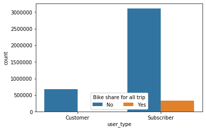

```python
ax = sb.countplot(data=bike_df, x='user_type', hue='bike_share_for_all_trip')
ax.legend(loc=8, ncol=2, framealpha=1, title='Bike share for all trip');
```

📝 **comment** 🔔 🔎

`user_type` and `bike_share_for_all_trip` is categorical variable so I choosed `clustered bar chart`.

`Bike share for all trip` is a annual plan for **Bay Area residents**. So its not surprising that people who is just a `customer`(who is not a subscriber) doesn't have `bike share for all trip` plan. And even for subscriber only `9.86%` are using the `bike share for all trip` plan. Considering the benefits it's not high.

### Talk about some of the relationships you observed in this part of the investigation. How did the feature(s) of interest vary with other features in the dataset? 🔔

> I could get more insights compared to univariate exploration at here. I could dive deep so could get user bike usage preferance related to `datetime`, `location`, `bike usage time`. **Relationships of bike, time, and space** allow me to understand more in-depth showing me `user use a bike at specific time at specific location`, `user's bike route`, `top10 bike's location` and more etc.

> **Our main feature of interest is `time` and `space`.** By combining `bike start hour` with `bike usage time` we could see the user always use bike around **6 minutes**, and when we combine `bike start hour` with `bike start day` we could see the **11-12th 8am and 5pm** is the most usage date. **Even it is a same feature depending on what other feature it combines it gives different stories and insights**.

It was interesting time to get more in-depth insights by the relationships of the variables!

**`datetime` vs `bike usage time`**

I thought `bike usage time distribution` for each `bike start hour` distribution was going to show me different shapes! Different from expectation the distribution showed **normal distribution** in log scale for all hours. The expectation was that the peak(mean) of normal distribution might vary a lot depending on the `hour` but it was wrong. Still most of the user use the bike for **6 minutes** no matter what time is it. Quite interesting! What is the meaning of **6 mintues?** Can't tell! No more informations to guess here!  
**`datetime` vs `datetime`**

I made relationships inside the `datetime`! The datetime have four features, `year`, `month`, `day`, and `hour`. The results I got was not different as what I got from `univariate exploration!`. **February** and **8am & 5pm** was the hotest datetime for the bike usage!

But one thing that looked interesting cameout! `month` vs `day` heatmap shows `diagonal pattern` of the bike usage frequency. **Why people's `the most bike usage days` does not stuck in one days like 11-12th and move to backward like `moving window`** as month goes? That was weird.

**`datetime` vs `location`**

Now I moved to relationship between `datetime` and `location`! We know that **February** and **8am & 5pm** is the hotest datetime and where people are using bike at this moments! I explored this with the `bike station` with `hour`!

- People start to use bike near **public transportation** at `8am` more than `5pm`
- People end the use of bike near **public transportation** at `5pm` more than `8am`

`Berry St at 4th St` acts opposite with the above explanation. If we dive more deep this kind of `station` will came our more. We can make assumption that people using `caltrain` is coming from other area to work and people who lives at `San Francisco` go to work using bike near `Berry St at 4th St`. Well **the point is many people are using bike as the next tool to move after the `public transportation` or to go to the there**.

**`location` vs `location`**

Now we could get curiosity of the users route using bike. By looking at the relationship between `location` and `location` we could get informations of these! By grouping up with **start and end station** we could find which route is the most popular route!

- `San Francisco Ferry Building (Harry Bridges Plaza)` to `The Embarcadero at Sansome St`
- 16313 times used

Trend of route but seems hard to get intuitive understanding with just names. We need a map that shows the route for precise understanding! Even I limited the number of station to `top10` it seems messy! One thing I found interesting is users end using the bike where they rental it! It means they are not using bike to move to somewhere. Rather they are using bike for wandering around for travel.

Then we could think about what station is the most popular one to comeback after riding?

- Total **504** station are used like this!
- `The Embarcadero at Sansome St` is the popular one recording `5071` times!

**Then how long they ride for this purpose? Just to look around and comeback?**

- **98.2%** of users ride less than `5 minutes`
- Other **1.8%** users ride more than `5 minutes` doesn't exceed **`25 minutes`**

**`bike` vs `location`**

I also looked at the relationship between the bike and the location! I compared the `top10 the most used bikes` with the `location` to find out where is the bike located at?

**The 10 most popular bike's location** were the places that is known **most popular stations of lyft bike service**. The **public transportation**. This is not surprising results. I was hoping to find some interesting results but came out ordinary.